# S1_Gauss

Author

Romina Loayza and Alfredo Aro

# Sesión 1: Regresión Gaussiana

Instructores:

- Romina Ariana Loayza Gaitán
- Alfredo Ludmir Aro Terleira

Material referencial: José Manuel Magallanes Reyes

## 1. Introducción

La regresión resulta una ténica en la que debemos definir una variable dependiente y una o más independientes. Las variables independientes no siempre cuentan con un rol predictor, pero sí explicativo; es por ello que resulta una ténica para probar hipótesis direccionales o asimétricas.

La regresión Gaussiana se usa cuando nuestra **variable dependiente (Y) resulta ser numérica, continua, y no acotada.** Por ejemplo:

- Presupuestos, gasto gubernamental
- Ingreso anual
- Altura, peso

## 2. Caso de estudio: Pavimentando con votos

Profesores de la Universidad de los Andes (Mejia Guinand, Botero, and Rodriguez Raga 2008) decidieron estudiar cómo la *distribución de fondos públicos* fue afectada por *factores políticos* durante el primer periodo del Presidente Uribe (2002-2006). Las hipótesis que se plantean son:

- H1: la asignación presupuestal en infraestructura vial en Colombia responde a los criterios técnicos y económicos determinados en el Plan Nacional de Desarrollo y otros documentos de carácter técnico elaborados por el gobierno.
- H2: la asignación presupuestal en infraestructura vial en Colombia responde a negociaciones bilaterales entre el ejecutivo y el legislativo basadas en necesidades políticas y electorales de corto plazo.
- H3: la asignación presupuestal en infraestructura vial en Colombia responde al esfuerzo del gobierno por fortalecer su base social de apoyo local a través de los Consejos Comunales de Gobierno

### 2.1. Preparación de los datos

Ya tenemos claras las hipótesis, podemos organizar los datos.

```r
rm(list = ls())    #esto nos sirve para limpiar el environment

#cargamos la data
link = 'https://docs.google.com/spreadsheets/d/e/2PACX-1vSRpCC8gKIxMxpK0wjgLcl-GQWdw6sAeB16Sixkq6kZXeTfMS8_n70twbEbQ2tMcGp8tm-6x8qf8ieo/pub?gid=234740779&single=true&output=csv'

#le damos un nombre
pavi = read.csv(link)
pavi
```

[output not shown]

[output cut: 2179 more lines]

Resulta importante como paso previo revisar el tipo de datos que tenemos, específicamente cómo es que R los ha leído:

```r
str(pavi)
```

```
'data.frame':   1096 obs. of  9 variables:
 $ municipio       : chr  "m1" "m2" "m3" "m4" ...
 $ apropiaciondolar: num  102.17 4.19 1.59 0 0 ...
 $ consejocomunal  : int  0 0 0 0 0 0 0 0 0 0 ...
 $ ejecucion       : int  0 0 0 0 0 0 0 0 0 0 ...
 $ uribista        : int  0 1 1 1 1 1 1 1 1 NA ...
 $ pctopo          : num  14.82 14.51 15.08 6.15 47.31 ...
 $ priorizado      : int  0 1 0 0 0 0 0 0 1 0 ...
 $ poblacioncienmil: num  20.9155 0.2406 0.0398 0.0558 0.2723 ...
 $ nbi             : num  12.2 33.8 28.5 33.1 27.1 ...
```

Recuerda que es mejor usar datos sin valores perdidos, por lo que tenemos que limpiar nuestra data:

```r
pavi=pavi[complete.cases(pavi),]
```

Asimismo, debemos darle el formato adecuado a nuestras variables. En nuestro caso hay que cambiar a categóricos algunas variables:

```r
seleccion=c("consejocomunal","ejecucion","uribista","priorizado")
pavi[,seleccion]=lapply(pavi[,seleccion],as.factor)

#Variable 0-1, que no se pueden leer como enteros
```

### 2.2. Explorando las variables

```r
paviStats=summary(pavi[,-1])    #el -1 es para que no tome la primera columna
paviStats
```

```
 apropiaciondolar  consejocomunal ejecucion uribista     pctopo
 Min.   :  0.000   0:827          0:844     0:325    Min.   : 0.000
 1st Qu.:  0.000   1: 49          1: 32     1:551    1st Qu.: 6.285
 Median :  0.000                                     Median :19.607
 Mean   :  8.926                                     Mean   :27.306
 3rd Qu.: 11.436                                     3rd Qu.:44.455
 Max.   :132.643                                     Max.   :99.419
 priorizado poblacioncienmil        nbi
 0:639      Min.   : 0.00629   Min.   : 6.84
 1:237      1st Qu.: 0.07460   1st Qu.:27.33
            Median : 0.14593   Median :40.26
            Mean   : 0.45639   Mean   :41.72
            3rd Qu.: 0.27433   3rd Qu.:53.78
            Max.   :69.26836   Max.   :97.32
```

Estas son las estadísticos básicos de nuestras variables, pero se muy flojo, por lo que tenemos que seguir.

## 3. Análisis de regresión

Veamos una hipótesis:

**Note**

*El Beneficio recibido* en un municipio ha sido afectado por *el porcentaje de votos recibidos por los candidatos de la oposición a Uribe a la camara de representantes*, controlando por *tamaño de población*.

```r
# hipótesis en R
modelo1 = formula(apropiaciondolar ~ pctopo + poblacioncienmil)
```

Para probar nuestra hipótesis en R, debemos realizar lo siguiente:

```r
reg1 = lm(modelo1, data=pavi)
summary(reg1)
```

```
Call:
lm(formula = modelo1, data = pavi)

Residuals:
    Min      1Q  Median      3Q     Max
-53.809  -8.671  -7.448   2.602  90.426

Coefficients:
                 Estimate Std. Error t value Pr(>|t|)
(Intercept)       8.80319    0.79976  11.007   <2e-16 ***
pctopo           -0.03146    0.02150  -1.463    0.144
poblacioncienmil  2.15125    0.20073  10.717   <2e-16 ***
---
Signif. codes:  0 '***' 0.001 '**' 0.01 '*' 0.05 '.' 0.1 ' ' 1

Residual standard error: 15.85 on 873 degrees of freedom
Multiple R-squared:  0.1181,    Adjusted R-squared:  0.1161
F-statistic: 58.45 on 2 and 873 DF,  p-value: < 2.2e-16
```

Si queremos presentarlo de una mejor forma, podemos emplear el **modelsummary package.**

```r
library(modelsummary)    #recordar como instalar paquetes
model1 = list("apropiacion (I)" = reg1)
modelsummary(model1, title = "Regresion: modelo 1",
             stars = TRUE,
             output = "kableExtra")
```

Regresion: modelo 1

|  | &nbsp;apropiacion (I) |
| --- | --- |
| (Intercept) | 8.803*** |
|  | (0.800) |
| pctopo | -0.031 |
|  | (0.021) |
| poblacioncienmil | 2.151*** |
|  | (0.201) |
| Num.Obs. | 876 |
| R2 | 0.118 |
| R2 Adj. | 0.116 |
| AIC | 7332.6 |
| BIC | 7351.7 |
| Log.Lik. | -3662.298 |
| F | 58.447 |
| RMSE | 15.83 |

+ p < 0.1, * p < 0.05, ** p < 0.01, *** p < 0.001

Al probar esta hipótesis vemos lo siguiente:

1. que *pctopo* tiene signo negativo (relación inversa con la VD)
2. que la *magnitud* de ese efecto es -0.031, lo que indica cuanto varía *apropiaciondolar* en promedio cuando *pctopo* se incremente en una unidad, controlando por *poblacioncienmil*.
3. que *pctopo* NO tiene *efecto significativo*.

Podemos representar esta información de la siguiente forma:

**Note**

apropiaciondolar=8.8031897+−0.0314583⋅pctopo+2.1512469⋅poblacioncienmil+ϵ

**Note**

¿Y si queremos ver el efecto de consejo comunal (*consejocomunal*)?

```r
#Esta resulta nuestra hipótesis 2
modelo2 = formula(apropiaciondolar ~ pctopo + consejocomunal + poblacioncienmil)
```

Esta nueva hipótesis pretende evaluar si la visita de Uribe a un Consejo Comunal influye en la asignación de presupuesto. Veamos el resultado:

```r
reg2= lm(modelo2,data=pavi)
summary(reg2)
```

```
Call:
lm(formula = modelo2, data = pavi)

Residuals:
    Min      1Q  Median      3Q     Max
-62.378  -7.933  -6.834   1.573  91.247

Coefficients:
                 Estimate Std. Error t value Pr(>|t|)
(Intercept)       8.04119    0.79129  10.162  < 2e-16 ***
pctopo           -0.02987    0.02103  -1.420    0.156
consejocomunal1  14.79601    2.32127   6.374 2.98e-10 ***
poblacioncienmil  1.91236    0.19987   9.568  < 2e-16 ***
---
Signif. codes:  0 '***' 0.001 '**' 0.01 '*' 0.05 '.' 0.1 ' ' 1

Residual standard error: 15.51 on 872 degrees of freedom
Multiple R-squared:  0.1573,    Adjusted R-squared:  0.1545
F-statistic: 54.28 on 3 and 872 DF,  p-value: < 2.2e-16
```

Recordar que el número de asteríscos nos revelan la significancia.

Si queremos una mejor visualización:

```r
model2=list('apropiacion (II)'=reg2)
modelsummary(model2, title = "Regresion: modelo 2",
             stars = TRUE,
             output = "kableExtra")
```

Regresion: modelo 2

|  | &nbsp;apropiacion (II) |
| --- | --- |
| (Intercept) | 8.041*** |
|  | (0.791) |
| pctopo | -0.030 |
|  | (0.021) |
| consejocomunal1 | 14.796*** |
|  | (2.321) |
| poblacioncienmil | 1.912*** |
|  | (0.200) |
| Num.Obs. | 876 |
| R2 | 0.157 |
| R2 Adj. | 0.154 |
| AIC | 7294.7 |
| BIC | 7318.6 |
| Log.Lik. | -3642.351 |
| F | 54.277 |
| RMSE | 15.47 |

+ p < 0.1, * p < 0.05, ** p < 0.01, *** p < 0.001

Observamos con esta nueva hipótesis que:

1. *pctopo* tiene signo negativo; NO tiene *efecto significativo*; y la *magnitud* de ese efecto es -0.03, lo que indica cuanto varíaría *apropiaciondolar* en promedio cuando *pctopo* se incremente en una unidad, controlando por las demás variables.
2. *consejocomunal* SÍ tiene *efecto significativo* al **0.001**; ese efecto es *directo*, pues el coeficiente calculado es positivo; y la *magnitud* de ese efecto es 14.796, lo que indica cuanto varía *apropiaciondolar* en promedio cuando *consejocomunal* es **1** y no **0**, también controlando por las demás variables.

Cómo leer el efecto cuand ola variable independiente es categórica o factor!!!!

Podemos tener la siguiente ecuación:

**Note**

apropiaciondolar= 8.0411893+−0.0298691⋅pctopo+14.7960149⋅consejocomunal+1.9123628⋅poblacioncienmil+ϵ

**Note**

Ahora queremos añadir el predictor **uribista,** veamos lo siguiente:

```r
# hipótesis 3
modelo3 = formula (apropiaciondolar ~ pctopo + consejocomunal + uribista + poblacioncienmil)

reg3=lm(modelo3,data=pavi)
summary(reg3)
```

```
Call:
lm(formula = modelo3, data = pavi)

Residuals:
    Min      1Q  Median      3Q     Max
-61.004  -7.546  -6.482   1.847  91.958

Coefficients:
                 Estimate Std. Error t value Pr(>|t|)
(Intercept)       9.80542    1.11705   8.778  < 2e-16 ***
pctopo           -0.03753    0.02126  -1.765   0.0779 .
consejocomunal1  14.73795    2.31613   6.363 3.19e-10 ***
uribista1        -2.45126    1.09801  -2.232   0.0258 *
poblacioncienmil  1.89052    0.19965   9.469  < 2e-16 ***
---
Signif. codes:  0 '***' 0.001 '**' 0.01 '*' 0.05 '.' 0.1 ' ' 1

Residual standard error: 15.47 on 871 degrees of freedom
Multiple R-squared:  0.1621,    Adjusted R-squared:  0.1583
F-statistic: 42.14 on 4 and 871 DF,  p-value: < 2.2e-16
```

Lo vemos de mejor forma:

```r
model3=list('apropiacion (III)'=reg3)
modelsummary(model3, title = "Regresion: modelo 3",
             stars = TRUE,
             output = "kableExtra")
```

Regresion: modelo 3

|  | &nbsp;apropiacion (III) |
| --- | --- |
| (Intercept) | 9.805*** |
|  | (1.117) |
| pctopo | -0.038+ |
|  | (0.021) |
| consejocomunal1 | 14.738*** |
|  | (2.316) |
| uribista1 | -2.451* |
|  | (1.098) |
| poblacioncienmil | 1.891*** |
|  | (0.200) |
| Num.Obs. | 876 |
| R2 | 0.162 |
| R2 Adj. | 0.158 |
| AIC | 7291.7 |
| BIC | 7320.4 |
| Log.Lik. | -3639.852 |
| F | 42.140 |
| RMSE | 15.43 |

+ p < 0.1, * p < 0.05, ** p < 0.01, *** p < 0.001

Al probar la tercera hipótesis podemos ver que:

Podemos proponer la siguiente ecuación:

**Note**

apropiaciondolar=9.8054173+−0.0375299⋅pctopo+14.7379501⋅consejocomunal+−2.4512573⋅uribista+1.8905189⋅poblacioncienmil+ϵ

### 3.1. Estandarización de Coeficientes

Del resultado de la última tabla NO podemos directamente decir que consejo comunal tiene más efecto que los demás por el solo hecho que el valor estimado sea mayor a los demás. Para saber cuál tiene más efecto, cuando los predictores tienen, como en este caso unidades diferentes, estandarizamos los datos y volvemos a correr la regresión.

```r
library(lm.beta)
model3beta=list('apropiacion (III)'=lm.beta(reg3))
modelsummary(model3beta, title = "Regresion: modelo 3 con \ncoeficientes estandarizados usando lm.beta()",
             stars = TRUE,
             output = "kableExtra")
```

Regresion: modelo 3 con coeficientes estandarizados usando lm.beta()

|  | &nbsp;apropiacion (III) |
| --- | --- |
| pctopo | -0.055 |
|  | (0.021) |
| consejocomunal1 | 0.201* |
|  | (2.316) |
| uribista1 | -0.070 |
|  | (1.098) |
| poblacioncienmil | 0.299 |
|  | (0.200) |
| Num.Obs. | 876 |
| R2 | 0.162 |
| R2 Adj. | 0.158 |
| AIC | 7291.7 |
| BIC | 7320.4 |
| Log.Lik. | -3639.852 |
| RMSE | 15.43 |

+ p < 0.1, * p < 0.05, ** p < 0.01, *** p < 0.001

## 4. Selección de modelos

Estuvimos intentando probar 3 hipótesis distintas, pero queremos saber cuál es la indicada

```r
models=list("apropiacion (I)" = reg1,
  "apropiacion (II)" = reg2,
  "apropiacion (III)" = reg3)

modelsummary(models, title = "Resultados de todos los modelos",
             stars = TRUE,
             output = "kableExtra")
```

Resultados de todos los modelos

|  | &nbsp;apropiacion (I) | &nbsp;apropiacion (II) | &nbsp;apropiacion (III) |
| --- | --- | --- | --- |
| (Intercept) | 8.803*** | 8.041*** | 9.805*** |
|  | (0.800) | (0.791) | (1.117) |
| pctopo | -0.031 | -0.030 | -0.038+ |
|  | (0.021) | (0.021) | (0.021) |
| poblacioncienmil | 2.151*** | 1.912*** | 1.891*** |
|  | (0.201) | (0.200) | (0.200) |
| consejocomunal1 |  | 14.796*** | 14.738*** |
|  |  | (2.321) | (2.316) |
| uribista1 |  |  | -2.451* |
|  |  |  | (1.098) |
| Num.Obs. | 876 | 876 | 876 |
| R2 | 0.118 | 0.157 | 0.162 |
| R2 Adj. | 0.116 | 0.154 | 0.158 |
| AIC | 7332.6 | 7294.7 | 7291.7 |
| BIC | 7351.7 | 7318.6 | 7320.4 |
| Log.Lik. | -3662.298 | -3642.351 | -3639.852 |
| F | 58.447 | 54.277 | 42.140 |
| RMSE | 15.83 | 15.47 | 15.43 |

+ p < 0.1, * p < 0.05, ** p < 0.01, *** p < 0.001

Podemos cambiar la anterior tabla, para que en lugar de observar los **errores típicos**, se muestren los **intervalos de confianza** del coeficiente estimado:

```r
models=list('apropiacion (I)'=reg1,
            'apropiacion (II)'=reg2,
            'apropiacion (III)'=reg3)

modelsummary(models, title = "Resultados de todos los modelos",statistic = "conf.int",
             stars = TRUE,
             output = "kableExtra")
```

Resultados de todos los modelos

|  | &nbsp;apropiacion (I) | &nbsp;apropiacion (II) | &nbsp;apropiacion (III) |
| --- | --- | --- | --- |
| (Intercept) | 8.803*** | 8.041*** | 9.805*** |
|  | [7.234, 10.373] | [6.488, 9.594] | [7.613, 11.998] |
| pctopo | -0.031 | -0.030 | -0.038+ |
|  | [-0.074, 0.011] | [-0.071, 0.011] | [-0.079, 0.004] |
| poblacioncienmil | 2.151*** | 1.912*** | 1.891*** |
|  | [1.757, 2.545] | [1.520, 2.305] | [1.499, 2.282] |
| consejocomunal1 |  | 14.796*** | 14.738*** |
|  |  | [10.240, 19.352] | [10.192, 19.284] |
| uribista1 |  |  | -2.451* |
|  |  |  | [-4.606, -0.296] |
| Num.Obs. | 876 | 876 | 876 |
| R2 | 0.118 | 0.157 | 0.162 |
| R2 Adj. | 0.116 | 0.154 | 0.158 |
| AIC | 7332.6 | 7294.7 | 7291.7 |
| BIC | 7351.7 | 7318.6 | 7320.4 |
| Log.Lik. | -3662.298 | -3642.351 | -3639.852 |
| F | 58.447 | 54.277 | 42.140 |
| RMSE | 15.83 | 15.47 | 15.43 |

+ p < 0.1, * p < 0.05, ** p < 0.01, *** p < 0.001

Si queremos verlo de forma mucho más gráfica, podemos correr el siguiente código:

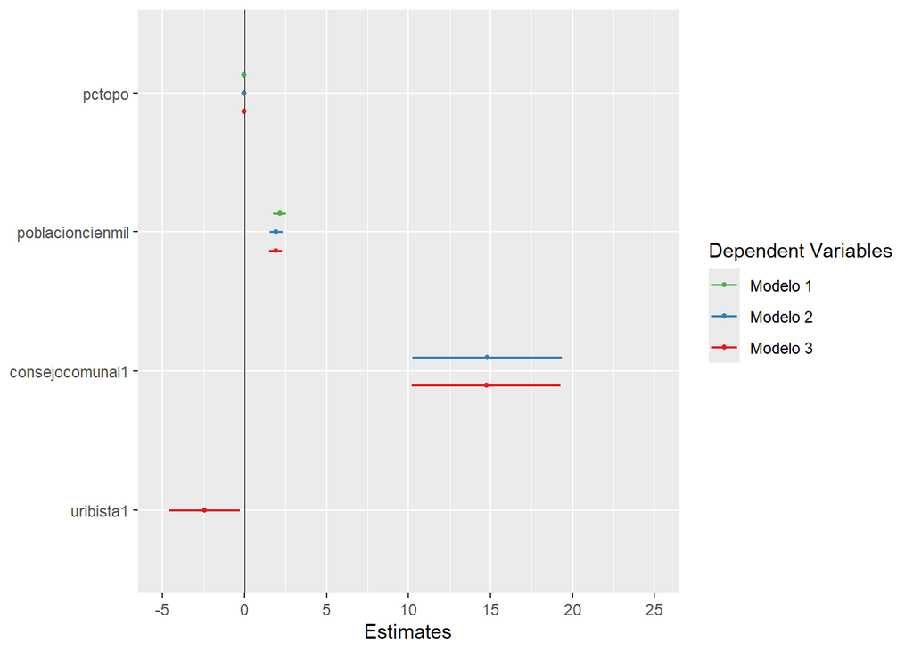

```r
library(ggplot2)
library(sjPlot)
plot_models(reg1,reg2,reg3,vline.color = "black",m.labels=c("Modelo 1","Modelo 2","Modelo 3"),dot.size = 1,line.size = 0.6)
```

Para comparar los modelos, debemos realizar la tabla **ANOVA**:

```r
library(magrittr)
library(knitr)
tanova=anova(reg1,reg2,reg3)

#Recordar que la tabla anova sirve para datos anidados

kable(tanova,
      caption = "Tabla ANOVA para comparar modelos")%>%kableExtra::kable_styling(full_width = FALSE)
```

Tabla ANOVA para comparar modelos

| Res.Df | RSS | Df | Sum of Sq | F | Pr(>F) |
| --- | --- | --- | --- | --- | --- |
| 873 | 219454.2 | NA | NA | NA | NA |
| 872 | 209684.3 | 1 | 9769.883 | 40.814973 | 0.0000000 |
| 871 | 208491.3 | 1 | 1192.989 | 4.983868 | 0.0258382 |

## 5. Diagnósticos de la Regresión

Debemos analizar los resultados obtenidos para poder tener una mejor conclusión. Revisemos el resultado de la segunda regresión en las siguientes sub-secciones:

### 5.1. Linealidad

Se asume relación lineal entre la variable dependiente (Y) y las independientes y Xs. Para ello analizamos la relación entre los residuos y los valores que predice el modelo de regresión.

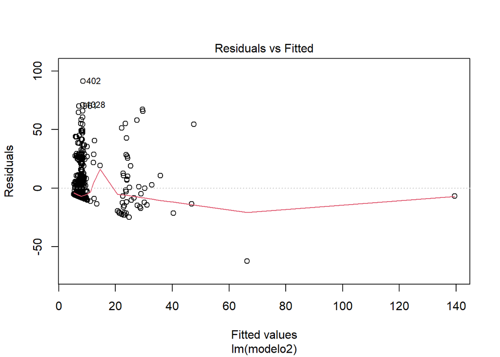

```r
# línea roja debe tender a horizontal
plot(reg2, 1)
```

Podemos verlo de la siguiente forma:

```r
mean(reg2$residuals)
```

```
[1] 1.351455e-15
```

- La falta de linealidad provocaría que el modelo no sirva para explicar las mismas variables con datos diferentes en otros estudios.

### 5.2. Homocedasticidad

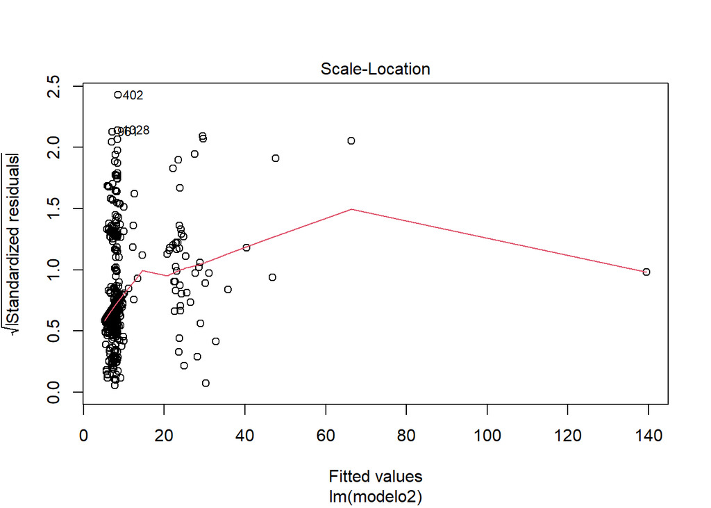

```r
# linea roja debe tender a horizontal
plot(reg2, 3)
```

No hay que confiarnos del gráfico! Es mejor realizar el test de Breusch-Pagan:

```r
library(lmtest)
library(kableExtra)
# null: modelo homocedastico
resBP=bptest(reg2)
data.frame(list('BP'=resBP$statistic,
             'df'=resBP$parameter,
             "p-value"=resBP$p.value))%>%
    kable(caption = resBP$method)%>%kable_styling(full_width = F)
```

studentized Breusch-Pagan test

|  | BP | df | p.value |
| --- | --- | --- | --- |
| BP | 34.83587 | 3 | 1e-07 |

- En este caso si el resultado del p-value es menor a 0.05 nos indica que hay heterocedasticidad en el modelo.
- p-value > 0.05 existe homocedasticidad
- p-value < 0.05 rechazamos que el modelo muestre homocedasticidad, por lo que encontrarmos heterocedasticidad

### 5.3. Normalidad de residuos

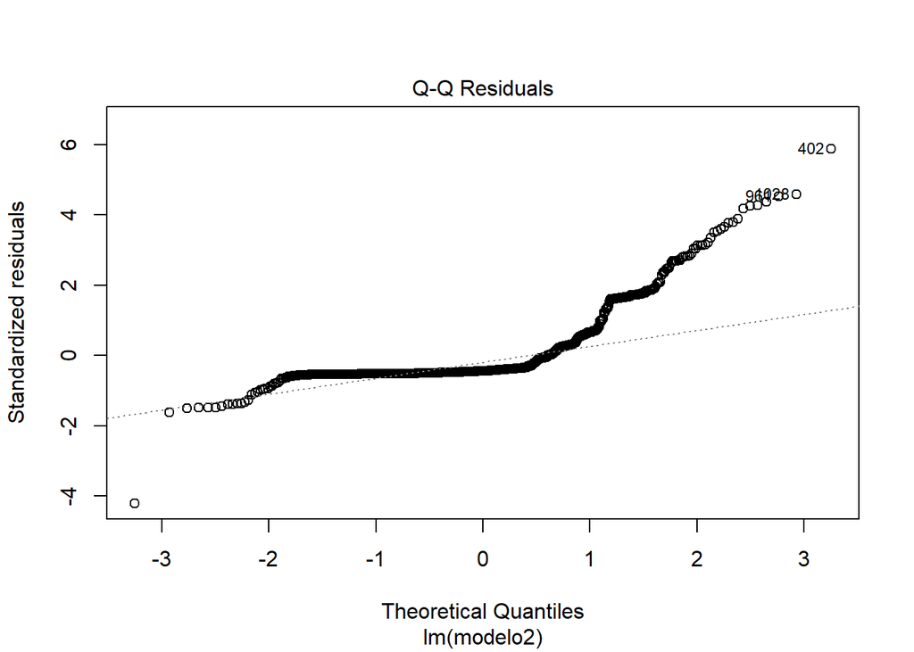

```r
plot(reg2, 2)
```

Mejor hagamos el test de Shapiro:

```r
resSW=shapiro.test(reg2$residuals)
data.frame(list('SW'=resSW$statistic,
             "p-value"=resSW$p.value))%>%
    kable(caption = resSW$method)%>%kable_styling(full_width = F)
```

Shapiro-Wilk normality test

|  | SW | p.value |
| --- | --- | --- |
| W | 0.6820371 | 0 |

### 5.4. No Multicolinealidad

Si los predictores tienen una correlación muy alta entre sí, hay multicolinealidad.

```r
library(DescTools)
# ideal menor a 3, aceptable menor a 5, mayor a 5 es problematico

VIF(reg2) %>%kable(col.names = "VIF",caption ="Evaluando Multicolinealidad usando VIF (Variance Inflation Factors)" )%>%kable_styling(full_width = F)
```

Evaluando Multicolinealidad usando VIF (Variance Inflation Factors)

|  | VIF |
| --- | --- |
| pctopo | 1.000152 |
| consejocomunal | 1.036568 |
| poblacioncienmil | 1.036454 |

### 5.5. Valores influyentes

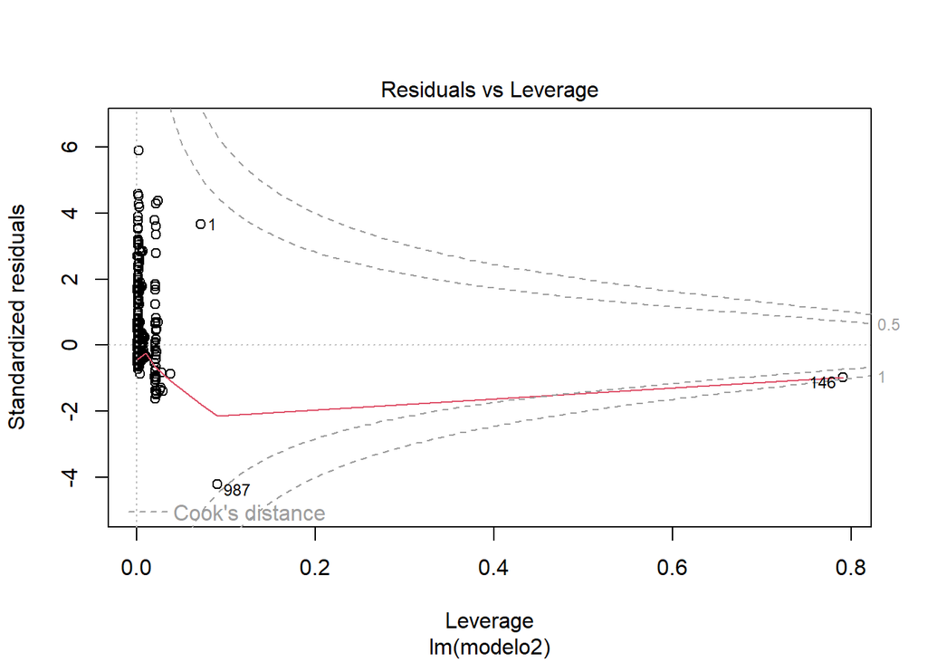

```r
plot(reg2, 5)
```

No nos confiemos de la gráfica!

```r
checkReg2=as.data.frame(influence.measures(reg2)$is.inf)
checkReg2[checkReg2$cook.d & checkReg2$hat,c('cook.d','hat')]%>%kable(caption = "Valores Influyentes criticos")%>%kable_styling(full_width = F)
```

Valores Influyentes criticos

|  | cook.d | hat |
| --- | --- | --- |
| 146 | TRUE | TRUE |

## Bibliografía

Mejia Guinand, Luis Bernardo, Felipe Botero, and Juan Carlos Rodriguez Raga. 2008. “¿Pavimentando con votos? Apropiación presupuestal para proyectos de infraestructura vial en Colombia, 2002-2006.” *Colombia Internacional*, no. 68: 14–42. http://www.redalyc.org/articulo.oa?id=81211204002.

MAGALLANES, Jose Manuel. 2022a. “Estadistica-AnalisisPolitico/Sesion1: Eap2 Classic.” Zenodo. https://doi.org/10.5281/ZENODO.7015029.